# Compound identification in metabolomics: an R approach

25-06-2021

## Compound identification

## Summary

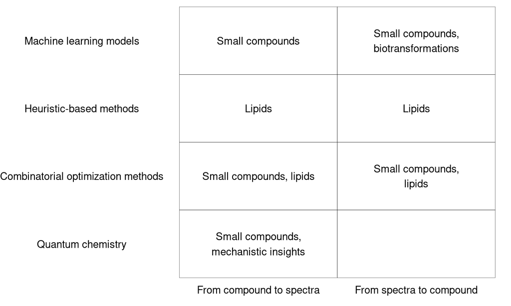

## Software

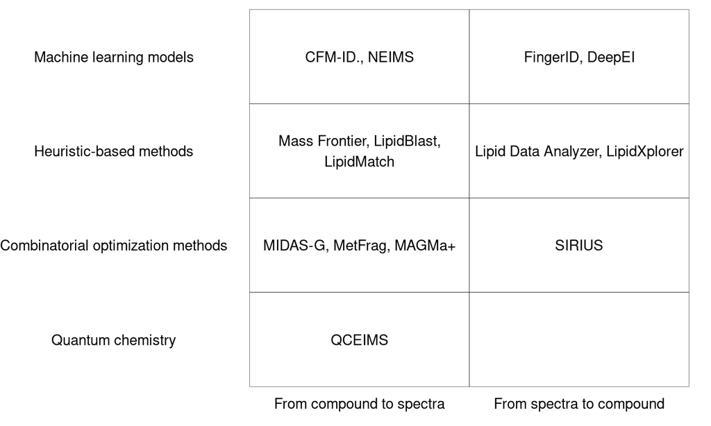

## CI workflow

## Two-step procedure

1. Identify the proper database using CEU Mass Mediator.
2. Do a MetFrag search using an identified database.

## CEU Mass Mediator

Available for the command line processing as an R package.

Gil-de-la-Fuente, A., Godzien, J., Saugar, S., Garcia-Carmona, R., Badran, H., Wishart, D.S., Barbas, C., and Otero, A. (2018). CEU Mass Mediator 3.0: A Metabolite Annotation Tool. Journal of Proteome Research.

## CEU Mass Mediator

```r
library(httr)
r <- POST("http://ceumass.eps.uspceu.es/api/batch",
          body = "Is anyone here?", encode = "json")

res <- try(stop_for_status(r), silent = TRUE)

print(res)
```

[output not shown]

## MetFrag

Ruttkies, C., Schymanski, E.L., Wolf, S., Hollender, J., and Neumann, S. (2016). MetFrag relaunched: incorporating strategies beyond in silico fragmentation. Journal of Cheminformatics 8, 3.

## MetFrag

```
## $DatabaseSearchRelativeMassDeviation
## [1] 5
##
## $FragmentPeakMatchAbsoluteMassDeviation
## [1] 0.001
##
## $FragmentPeakMatchRelativeMassDeviation
## [1] 5
##
## $MetFragDatabaseType
## [1] "PubChem"
##
## $NeutralPrecursorMass
## [1] 253.9661
```

## MetFrag

```
## $PeakList
##            [,1] [,2]
##  [1,]  90.97445  681
##  [2,] 106.94476  274
##  [3,] 110.02750  110
##  [4,] 115.98965   95
##  [5,] 117.98540  384
##  [6,] 124.93547  613
##  [7,] 124.99015  146
##  [8,] 125.99793  207
##  [9,] 133.95592  777
## [10,] 143.98846  478
## [11,] 144.99625  352
## [12,] 146.00410  999
## [13,] 151.94641  962
## [14,] 160.96668  387
## [15,] 163.00682  782
## [16,] 172.99055   17
## [17,] 178.95724  678
## [18,] 178.97725  391
## [19,] 180.97293  999
## [20,] 196.96778  720
## [21,] 208.96780  999
## [22,] 236.96245  999
## [23,] 254.97312  999
```

## MetFrag

```
## $NeutralPrecursorMolecularFormula
## [1] "C7H5Cl2FN2O3"
##
## $PrecursorCompoundIDs
## [1] "50465"    "57010914" "56974741" "88419651" "23354334"
##
## $MetFragPreProcessingCandidateFilter
## [1] "UnconnectedCompoundFilter" "IsotopeFilter"
##
## $MetFragPostProcessingCandidateFilter
## [1] "InChIKeyFilter"
```

## MetFrag - results

| NoExplPeaks | Score | MonoisotopicMass |
| --- | --- | --- |
| 18 | 1.0000000 | 253.9661 |
| 18 | 0.9206230 | 253.9661 |
| 16 | 0.8904217 | 253.9661 |

## MetFrag - results

- NoExplPeaks
- Score
- MonoisotopicMass
- SMILES
- InChIKey
- NumberPeaksUsed
- InChI
- MaximumTreeDepth
- Identifier
- ExplPeaks
- InChIKey2
- InChIKey1
- IUPACName
- FragmenterScore
- MolecularFormula
- FragmenterScore_Values
- FormulasOfExplPeaks
- XlogP3

## Summary

## General remarks

1. We are not limited to R.
2. Intented solution won’t be a command line tool, but rather a clickable interface.

## Questions

1. Why run CEU Mass Mediator at all? Instead, we can run MetFrag on all available databases.
2. What is the easiest way to import data? How to limit the number of clicks?
3. Can we make a solution independent from the web services?